# Análisis automático de sentencias judiciales. Modelar la respuesta a los casos por conducir con mayor alcohol en sangre que el permitido

Demian Zayat

2020-03-02

# Introducción

En Argentina, las sentencias judiciales estuvieron mayormente ausentes de los análisis de la ciencia de datos. Si bien existen algunos analisis empíricos en derecho, en general se centran en el funcionamiento de las instituciones o el impacto de las regulaciones, pero no suele encontrarse analisis de decisiones judiciales salvo, por supuesto, interesantes excepciones[^1].

Al mismo tiempo estamos en presencia del avance de proyectos de acceso a la información pública, y la liberación cada vez mayor de una gran cantidad de bases de datos, que tuvo un desarrollo muy amplio en estos últimos años en todas las áreas públicas como proyectos de datos abiertos[^2]. Sin embargo, el Poder Judicial suele ser reaccionario frente a la posibilidad de abrir los *dockets* de sentencias. El consejo de la Magistratura tampoco lleva adelante un programa concreto para la publicación en línea de todas las sentencias que se dictan a diario en los juzgados. Afortunadamente, algunos jueces y juezas sí pretenden disponibilizar sus sentencias en formato de datos abiertos y organizan vías de contacto no tradicionales con la ciudadanía (blogs, cuentas de Twitter, etc.).

En la Ciudad de Buenos Aires, el Juzgado Nº 13 y el Juzgado Nº 10 en lo Penal, Contravencional y de Faltas, iniciaron proyectos de publicación en línea tanto de la agenda de audiencias como del *docket* de sentencias y resoluciones. Así, a través de las cuentas de Twitter del juzgado (@jpcyf13, @jpcyf10), puede accederse a sendos repositorios abiertos que colgaron en Google Drive, y allí puede accederse a un índice base, con el link a cada una de las decisiones adoptadas desde que comenzaron el proyecto.

Estos indices base tienen mucha información de la causa: el tipo de causa que se trata, el artículo del código penal, contravencional o código de faltas juzgado, fecha de resolución, registro, etc, y en algún caso algunos datos sobre la persona imputada (sexo, edad, nacionalidad). El armado de este indice insume una gran cantidad de tiempo, y dificulta que mayor cantidad de juzgados se sumen a la iniciativa. Según manifiestan, no alcanza sólo con la voluntad de abrir los datos, sino que resulta necesario un trabajo a cargo del juzgado de subir las sentencias y clasificarlas en el índice.

Sin embargo, quizas sea posible codificar las sentencias de modo automático. Ello permitiría a una mayor cantidad de juezas y jueces a publicar sus sentencias al reducir la cantidad de trabajo que insumiría un proyecto de este tipo. Asimismo podría pensarse en trabajos de minería de texto para clasificar y realizar analisis temáticos de estas sentencias. Eso es lo que me propongo hacer en este trabajo.

En este trabajo no haré modelado de tópicos Ese modelado es útil para clasificar distintos argumentos por tópicos o temas que se analizan. Sin embargo, las sentencias penales, si bien están escritas en lenguaje natural, son categóricas en tanto si la parte resolutoria dice “absolver” la persona está absuelta y si dice “condenar” quedará condenada. Muchas veces, el lenguaje judicial es constitutivo de relaciones jurídicas[^3]. Entonces, en este trabajo buscaré estas palabras que definen las relaciones jurídicas, principalmente con las expresiones regulares y el paquete `stringr`.

Comenzaré a analizar el repositorio del Juzgado 13, y clasificaré las sentencias de acuerdo a algunas expresiones regulares que me permitan realizar la tipificación de modo automático. Usaré solo los links a los archivos, ignorando el resto de los datos que pretenderé extraerlos directamente del texto de la sentencia. Luego, seleccionaré aquellas que sean por infracción al artículo 118 del Código Contravencional (conducir con mayor cantidad de alcohol en sangre del permitido o bajo los efectos de estupefacientes) que es una de las infacciones más frecuentes (con mayor cantidad de sentencias) que resuelve el juzgado, para ver si es posible clasificar el tipo de respuestas de acuerdo al tipo de infracción.

Una vez fabricada la base de datos a partir de los links con los textos de las sentencias, analizaré sus resultados. Realizaré, de acuerdo a lo estudiado, una regresión lineal, un modelo CART y un ensamble Random Forest. Luego intentaré interpretar estos resultados.

Por último, si queda tiempo, analizaré el dataset del juzgado 10 con este mismo código, para ver si es posible realizar el mismo análisis con otro repositorio. Esto nos permitirá comprobar si el código es facilmente reproducible y adaptable a otros juzgados que decidan disponibilizar sus datos.

# Construcción de la base de datos de sentencias

Primero descargaré el índice del repositorio del juzgado 13 para el año 2019, y me centraré únicamente en la columna de los links, para ir construyendo una grilla propia.

```r
knitr::opts_chunk$set(warning = FALSE, message = FALSE)
options(scipen = 999)
#carga de la base 2019, previamente pasada a csv
repo <- read_csv("https://github.com/Demzayat/varios/raw/master/Modulo6/repo_2.csv")
```

Muchas de estas decisiones no tienen el link disponible, ya sea porque aún no se dictó ninguna decisión, o por alguna otra razón. Asimismo, también comprobé que hay varios links que dicen “Resolución Oral” u otros equivalentes, que trabaron la descarga. Luego de probar varias veces, logré el siguiente filtrado.

```r
errores <- c(26, 24, 463,238,239, 232,233,234, 307, seq(570,581), 886)
linkes <- repo %>%
    filter(!is.na(Link)) %>%
    filter(!`Nro. de asiento digital`%in% errores) #elimino errores de link o falta de permisos
```

Una vez seleccionados los links, habrá que leerlos y convertirlos a texto plano para que sean una columna. Para ello armo una función y los descargo.

```r
descarga_link <- function(link){
  drive_download(as_id(as.character(link)[1]),
                 path = "temporal.odt", overwrite = TRUE)
  readtext("temporal.odt",ignore_missing_files= TRUE)[1,2]
}
linkes <- linkes %>%
  mutate(texto = map(Link, descarga_link))
```

Este código no funcionó. Un primer problema que presenta este repositorio es que algunos archivos están en formato `.odt`, otros en `.doc` y otros en `.docx`. Cuando alguno no está en formato `.odt` salta un error. Entonces tendré que tomar otro camino: construyo una tabla temporal con el nombre y extensión del archivo y link, luego descargo todos los archivos al disco rígido, y por último leo esos archivos por nombre con un loop. Esto va a llevar una cantidad considerable de tiempo.

```r
temporal <- drive_reveal(as_id(as.character(linkes$Link)), what = "path")

texto <- data_frame(texto = NA )
for(i in 1:nrow(temporal)){
    drive_download(file= as_id(temporal$id[i]), overwrite = TRUE)
    texto[i,] = readtext(file = temporal$name[i])[2]
    }
```

Conseguí de este modo una tabla con el texto de las 1065 decisiones judiciales.

```r
head(texto, 10)
```

```
## # A tibble: 10 x 1
##    texto
##    <chr>
##  1 "En la CiudadAutónoma de Buenos Aires, al primer día del mes de febrero…
##  2 "Buenos Aires,       de febrero de 2019.\nPor recibido. Tengo presente …
##  3 "Juzgado Nº 13, Secretaría única\n\nBuenos Aires,     de febrero de 201…
##  4 "ACTA DE AUDIENCIA\nCausa Nro.:43808/18\nCarátula:“B****, Gonzalo Alexi…
##  5 "Buenos Aires, defebrero de 2019.\nPara resolver en lacausa n°24906/18(…
##  6 "Buenos Aires, demayode 2019.\nPara resolver sobre el pedido de incompe…
##  7 "Buenos Aires, de febrero de 2019.\nPara resolver en lacausa n° 15893/1…
##  8 "ACTA DE AUDIENCIA\nCausa Nro.:8616/19(Reg. int.51/C/19)\nCarátula:“F**…
##  9 "ACTA DE AUDIENCIA\nCausa Nro.:13896/19(Reg. int.82/C/18)\nCarátula:“C*…
## 10 "Nombre del Expediente:“EMPRESA MONSERRAT SERVICIOS SOCIALES SRLs/ infr…
```

La lectura a través del paquete `readtext` dejó muchas palabras pegadas, lo que es va a generar un problema, y muchos caracteres especiales. Puedo sacar los `\n` y convertirlos en espacios.

```r
 texto <- mutate(texto, texto = str_replace_all(texto, pattern = '\n',replacement = ' '))
```

Y ahora puedo construir algunas columnas descriptivas. Puedo clasificar si la decisión fue un acuerdo de juicio abreviado, y el tipo de infracción que se está juzgando. Asimismo, separar la parte resolutiva de la sentencia.

```r
### agrego columnas
texto <- texto %>%
    mutate(abreviado = case_when(str_detect(texto, 'acuerdo de juicio abreviado|ACUERDO DE JUICIO ABREVIADO')~ 1,
                                 TRUE~ 0),
           probation = case_when(str_detect(texto, 'proceso a prueba|PROCESO A PRUEBA') & abreviado == 0~ 1,
                                 TRUE~ 0),
            infraccion = str_extract(texto, '(SOBRE)(.*)(.?")|(s/)(.*)(.?")|(S/)(.*)(.?")|(sobre)(.*)(.?")|(sobre)(.*)(.?")|(infr. Art.)(.*)(.?\\. ")|previst(.*)(.?")|previst(.?){50}|(infracci?n al)(.?){50}'),
           incompetencia = case_when(str_detect(texto, 'incompetencia|INCOMPETENCIA')~ TRUE,
                                 TRUE~ FALSE))

texto <- texto %>%
           mutate(infraccion = str_remove(infraccion, "SOBRE|s/|S/|sobre|previsto"))
texto <- texto %>%
    mutate(resuelve = str_extract(texto, '(RESUELV)(.*)(costas)|(RESUELV)(.*)(doy fe.)|(RESUELV)(.*)(archívese.)|(RESUELV)(.*)(archivo)|(RESUELV)(.*)(Ante mí)'))
```

Este código fue construido a través de prueba y error manual hasta dar con una clasificación aceptable. Por supuesto hay errores que surgen en virtud de que en la base hay algunos textos que son leidos con el espaciado incorrecto, lo que hace que las expresiones codificadas no sean reconocidas, o con errores de tipeo (del estilo “RESULEVO” por “RESUELVO”), etc. De todos modos, estos errores no deberían ser importantes en la gran cantidad de datos.

# Construcción de la base de datos de alcohol en sangre

Con esta clasificación hecha, puedo seleccionar las sentencias de los casos por infracción al artículo 118 del Cód. Contravencional, que establece que **“Artículo 118 - Conducir con mayor cantidad de alcohol en sangre del permitido o bajo los efectos de estupefacientes -. Quien conduce un vehículo superando los límites permitidos de alcohol en sangre o bajo la acción de otras sustancias que disminuyan la aptitud para hacerlo, es sancionado/a con doscientos ($200) a dos mil ($2000) pesos de multa o uno (1) a diez (10) días de arresto. Admite culpa.”** El límite establecido para el alcohol es de 0.5 g/l para los automóviles y 0.2 g/l para las motocicletas y 0 para los taxis o vehículos profesionales.

Para la construcción de esta base, voy a extraer aquellas sentencias que en la infracción incluyan al artículo 118, y a partir de ello, agregar variables con la cantidad de alcohol detectado en la sentencia y el tipo de sanción que se aplicó.

```r
alcohol <- texto %>%
  mutate(sangre = case_when(str_detect(infraccion, '118')~ TRUE,
                                 TRUE~ FALSE)) %>%
  filter(sangre == TRUE)

alcohol <- alcohol %>%
    mutate(gl = str_extract(texto, '(.?.?.?.?.?)(g/l)|(.?.?.?.?.?)(g/L)|(.?.?.?.?.?)(gr/l)|(.?.?.?.?.?)(gr/L)|(.?.?.?.?.?)(grs/l)'))
alcohol <- alcohol %>%
    mutate (valor = as.numeric(str_remove_all(alcohol$gl, '\\D'))/100) %>%
  select(-sangre, -gl, -incompetencia, -infraccion)
```

Varias de estas sentencias no son las de fondo que resolvían el caso, sino algunas que tienen por cumplida la suspensión del juicio a prueba, o las condiciones impuestas. Al filtrar esas, puedo comenzar a clasificar las respuestas judiciales brindadas.

```r
#realizo funciones para calcular los dias de arresto, el monto de la multa, y el plazo de la inhabilitación para conducir

dias_arresto <- function(x){
    arresto <- str_extract(x,"(.?.?.?.?.?.?.?.?.?.?.? de arresto)|(.?.?.?.?.?.?.?.?.?.?. DE ARRESTO)")
    monto <- as.numeric(str_remove_all(arresto, "\\D"))
    monto
}
monto_multa <- function(x){
    multa <- case_when(str_detect(x, 'multa|MULTA') ~ str_extract(x, "(\\$)(.?){7}"))
    monto <-   as.numeric(str_remove_all(multa, "\\D"))
    monto
}
inhabilitado <- function(x){
    accesoria <- str_extract(x, "(accesoria)(.?){120}|(ACCESORIA)(.?){120}")
    monto <- as.numeric(str_remove_all(accesoria, "\\D"))
    medida <-  ifelse((str_detect(accesoria, "MESES|meses")), monto* 30, monto* 1)
    medida
}

alcohol <- alcohol %>%
   filter(!is.na(valor)) %>%
    mutate(absolucion = as.numeric(str_detect(resuelve, 'SOBRESEER|sobreseer')),
           arresto = dias_arresto(resuelve),
           multa = monto_multa(resuelve),
           inhabilitacion = inhabilitado(resuelve) )
```

Sin embargo, están quedando sin clasificar las sentencias donde se resuelve a través de una *probation*, es decir, una suspensión del juicio a prueba por cierto tiempo y con el compromiso de cumplir pautas de conducta que se fijan conjuntamente con la fiscalía, que son la mayoría. En general las pautas de conductas incluyen, en todos los casos, fijar domicilio y concurrir a las citaciones de la Fiscalía, y luego pueden constar en la realización de cierta cantidad de horas de tareas comunitarias, abstenerse de conducir por el plazo fijado, entregar una cantidad de insumos determinada a cierto hospital o asociación de beneficencia (que termina actuando como una multa), o concurrir a realizar algún curso de educación vial. Veamos cómo codificar eso.

```r
#funciones para calcular la cantidad de dias de spp, las horas de las tareas comunitarias, el plazo de abstención de conducir, y la condena en entregar insumos

computo <- function(x){
    plazo <- str_extract(x, "(por el término)(.?){20}")
    valor <-  as.numeric(str_remove_all(plazo, "\\D"))
    medida <-  ifelse((str_detect(plazo, "MESES|meses")), valor* 30, valor* 1)
     medida
}
tareas_horas <- function(x){
    spp_tareas <-  str_extract(x, "(tareas comunitarias)(.?){40}")
    valor <- as.numeric(str_remove_all(spp_tareas, "\\D"))
    valor
}
abstencion <- function(x){
    abstenerse <- str_extract(x, "(Abstenerse)(.?){70}|(abstenerse)(.?){70}")
    valor <- as.numeric(str_remove_all(abstenerse, "\\D"))
    valor
}
insumir <- function(x){
    entregar <- str_extract(x, "(Entregar insumos)(.?){120}")
    dinero <- str_extract(entregar, "(\\$)(.?){8}")
    monto <- as.numeric(str_remove_all(dinero, "\\D"))
    monto
}

#agregar al cuadro la codificación de la SPP

alcohol <- alcohol %>%
    mutate(spp_dias = case_when(abreviado == FALSE ~ computo(resuelve)),
           tareas_horas = tareas_horas(resuelve),
           abstenerse = abstencion(resuelve),
           insumos = insumir (resuelve),
           curso = as.numeric(str_detect(resuelve, "(asistir al curso)|(Asistir al curso)|(realizar el Curso)|(realizar el curso)")))
```

Ya tenemos la base de datos codificada con el valor del alcohol en sangre y los datos de las sentencias o acuerdos arribados. Podríamos pensar en agregar algunos datos sobre los infractores, quizás los más fáciles serían el sexo y la edad.

Para clasificar si cierto nombre es de varón o mujer, utilizaré la base de datos de `nombres propios` del repositorio oficial del GCBA[^4]. Los codifico numericamente asignando `0` al sexo masculino y `1` al femenino.

Con respecto a la edad, algunas sentencias establecen la fecha de nacimiento del imputado, seleccionaré ella y se la restaré a 2019 que es el año en donde se llevó adelante el juicio.

```r
#extraigo listas de nombres de varones y mujeres
nombres <- read_csv2("http://cdn.buenosaires.gob.ar/datosabiertos/datasets/nombres-permitidos/nombres-permitidos.csv")
varones <- nombres %>%
  filter(SEXO == "M") %>%
  pull(NOMBRE) %>%
  tolower()
mujeres <- nombres %>%
  filter(SEXO == "F") %>%
  pull(NOMBRE) %>%
  tolower()

#identifico la probabilidad del sexo segun el nombre
sexo <- function(x){
  caratula <- str_extract(x, "(Carátula)(.?){40}|(Imputado)(.?){40}|(caratulada)(.?){40}")
  caratula_min <- tolower(caratula)
  sexo <- case_when(sum(str_detect(caratula_min, varones))>sum(str_detect(caratula_min, mujeres)) ~ 0,
                    sum(str_detect(caratula_min, mujeres))>sum(str_detect(caratula_min, varones))~ 1)
  sexo
}

#funcion para detectar la edad

edad <- function(x){
    nacimiento <- str_extract(x, "(nacimiento)(.?){30}|(nacido)(.?){30}")
    anio <- as.numeric(str_remove_all(nacimiento, "\\D"))
    ultimos <- as.numeric(str_extract(anio, "[[:digit:]]{4}$"))
    edad <- 2019 - ultimos
    edad
}

#agrego sexo y edad a la base y reordeno
alcohol <- alcohol %>%
  add_column( sexo = map(alcohol$texto, sexo)) %>%
  mutate(edad = edad(texto)) %>%
  select(texto, resuelve, sexo, edad, valor, abreviado, probation, everything())

#save(alcohol, file = "alcohol.rdata")
```

Con todos estos datos, podemos dar por completada la base de datos. Veámos en lo que sigue qué relación existe entre estos datos.

# Modelos predictivos

El artículo 118 del código contravencional penaliza a quien conduzca con mayor cantidad de alcohol en sangre que la permitida. Lo que quiero analizar es si existe una relación entre la cantidad de alcohol en sangre detectada y la consecuencia penal que se contrae. Para ello, nuestra variable `y` será el `valor` de alcohol en sangre, y estará en relación con el resto de las variables, de modo tal que podrá probarse si existe algún tipo de relación con las variables explicativas. En realidad no nos interesa saber cuánto valor en sangre se puede deducir de la sentencia, sino justamente el camino inverso: dependiendo del valor de la cantidad de alcohol en sangre, *qué tipo de sentencia podría esperarse.* Como existen muchos tipos de sentencias distintas, es importante conocer el modelo que podría predecir el valor de alchol en sangre, para ver qué peso tienen las distintas variables de la sentencia.

Esta información podría ser muy valiosa para la defensa, que podrá saber a qué atenerse según la gravedad de la falta. También es útil para controlar a la fiscalía, y para el juzgado, para poder tener una pauta más o menos previsible de qué esperar. Cuando sigan siendo dictadas sentencias o resoluciones se podrá ir perfeccionando el modelo.

## Modelo 1. Regresión lineal

El primer modelo predictivo que vamos a analizar para conocer la relación entre las variables explicativas y la variable independiente será el de la regresión lineal. No utilizaré directamente `lm()` del paquete `stats` sino que voy a usar el `method = lm` en la función `train()` del paquete `caret`, estableciendo un control de validación cruzada. Para esto voy a dividir el dataset en `entrenamiento - train` y `prueba - test`. Lo voy a hacer con un 80% para entrenamiento y 20% para prueba, para entrenar un modelo y luego probar su precisión.

```r
#cargo de la base
alcohol <- readRDS(gzcon(url("https://github.com/Demzayat/varios/blob/master/Modulo6/alcohol.rds?raw=true")))
```

Lamentablemente, hay muchos valores faltantes `NA` en muchas variables. Salvo en la edad y el sexo, los `NA` en el resto de las variables significa que no sucedió, y por ello, serán reemplazados por `0`[^5]. Sin embargo, en la edad y en el sexo, esto distorsionaría los datos. Por ello, hasta que no haya una mayor cantidad de datos, voy a eliminar esas variables del modelo[^6]…

```r
#elimino las columnas de texto, más la edad y el sexo
alcohol <- alcohol %>%
  select(-texto, -resuelve, -sexo, -edad)
alcohol[is.na(alcohol)] <- 0 #Convierto los NA en 0
```

```r
## Regresion lineal
set.seed(1234)

#creo los dos datasets de entrenamiento y prueba
tr_index <- createDataPartition(y= alcohol$valor,
                                p=0.8, list=FALSE)

entrenamiento <- alcohol[tr_index,] #80%
prueba <- alcohol[-tr_index,]# 20%

#establezco un metodo de control con validación cruzada
fitControl <- trainControl(method="cv",
                            number=10)

#entreno el modelo
regresion <- train(valor ~. ,
                   data = entrenamiento,
                   method = "lm",
                 trControl = fitControl)
regresion
```

```
## Linear Regression
##
## 75 samples
## 11 predictors
##
## No pre-processing
## Resampling: Cross-Validated (10 fold)
## Summary of sample sizes: 68, 67, 69, 68, 67, 67, ...
## Resampling results:
##
##   RMSE       Rsquared   MAE
##   0.3501619  0.6115461  0.2250419
##
## Tuning parameter 'intercept' was held constant at a value of TRUE
```

```r
summary(regresion)
```

```
##
## Call:
## lm(formula = .outcome ~ ., data = dat)
##
## Residuals:
##      Min       1Q   Median       3Q      Max
## -0.56094 -0.12356 -0.00386  0.08162  0.51929
##
## Coefficients: (1 not defined because of singularities)
##                   Estimate  Std. Error t value      Pr(>|t|)
## (Intercept)     0.51000000  0.09871494   5.166 0.00000253384 ***
## abreviado       0.10529734  0.23209202   0.454      0.651588
## probation       0.04958676  0.13463185   0.368      0.713855
## absolucion              NA          NA      NA            NA
## arresto        -0.26806945  0.09741136  -2.752      0.007698 **
## multa           0.00021575  0.00012696   1.699      0.094109 .
## inhabilitacion -0.00011125  0.00131561  -0.085      0.932872
## spp_dias       -0.00561529  0.00133449  -4.208 0.00008197254 ***
## tareas_horas    0.02058677  0.00379854   5.420 0.00000096755 ***
## abstenerse      0.06550551  0.00975453   6.715 0.00000000586 ***
## insumos         0.00003712  0.00000950   3.907      0.000228 ***
## curso           0.10622914  0.06985929   1.521      0.133282
## ---
## Signif. codes:  0 '***' 0.001 '**' 0.01 '*' 0.05 '.' 0.1 ' ' 1
##
## Residual standard error: 0.2207 on 64 degrees of freedom
## Multiple R-squared:  0.7585, Adjusted R-squared:  0.7208
## F-statistic:  20.1 on 10 and 64 DF,  p-value: 0.0000000000000003629
```

Lo interesante de este resultado, más allá del $R^2$ de 0.6115461, es que tanto la cantidad de días de la suspensión del proceso a prueba (`spp_dias`), la cantidad de horas de tareas comunitarias (`tareas_horas`), la cantidad de días de abstenerse de manejar (`abstenerse`), y el monto de los insumos –o multa– que deben entregarse (`insumos`), son estadísticamente muy significativos en relación al `valor` de la cantidad de alcohol en sangre. Por su parte los días de `arresto` es también significativo.

Podemos ahora testear el dataset de prueba, obteniendo una predicción de los resutaldos de nuestra variable `valor`, y comparar los resultados con el real.

```r
regresion_predicta <- predict(regresion, prueba)

resultado_regresion <- tibble(real = prueba$valor,
                              M_regresion = round(regresion_predicta,2),
                              diferencia = M_regresion - real)

knitr::kable(resultado_regresion) %>%
  kable_styling(full_width = FALSE)
```

| real | M_regresion | diferencia |
| --- | --- | --- |
| 0.52 | 0.94 | 0.42 |
| 0.67 | 0.46 | -0.21 |
| 0.58 | 0.67 | 0.09 |
| 1.38 | 1.05 | -0.33 |
| 0.56 | 0.76 | 0.20 |
| 0.83 | 0.85 | 0.02 |
| 1.08 | 1.05 | -0.03 |
| 0.66 | 0.67 | 0.01 |
| 0.54 | 0.67 | 0.13 |
| 1.34 | 1.63 | 0.29 |
| 0.64 | 0.75 | 0.11 |
| 0.78 | 0.88 | 0.10 |
| 0.71 | 0.88 | 0.17 |
| 1.04 | 1.12 | 0.08 |
| 1.97 | 1.62 | -0.35 |
| 1.26 | 0.68 | -0.58 |

Con este modelo obtuvimos un modelo con $R^2$ de 0.6115461, y una predicción que en promedio se desvía de la real en 0.0075 y una dispersión de 0.2575914.

## Modelo 2. Arbol de Decisión

Quizás un arbol de decisión nos pueda dar más información sobre los posibles resultados de acuerdo a la cantidad de alcohol en sangre. El armado de un modelo de arbol de decisión deberá ser también testeado para ver cómo funciona.

Sin embargo, antes de hacer esta división del dataset, haré una primera corrida con todos los datos, ya que la mayor cantidad de datos nos da una mayor profundidad del árbol. Mantendremos el método de validación cruzada ya realizado en la regresión. Tunearemos los hiperparámetros desde 3 a 8 de profundidad, para elegir la mejor.

```r
fitControl <- trainControl(method="cv",
                            number=10)

grid <- expand.grid(maxdepth=c(3, 4, 5, 6, 7, 8))

cart_tune_100 <- train(valor ~ . ,
                 data = alcohol,  #100% de los datos
                 method = "rpart2",
                 trControl = fitControl,
                 tuneGrid = grid)
cart_tune_100
```

```
## CART
##
## 91 samples
## 11 predictors
##
## No pre-processing
## Resampling: Cross-Validated (10 fold)
## Summary of sample sizes: 83, 82, 81, 83, 83, 80, ...
## Resampling results across tuning parameters:
##
##   maxdepth  RMSE       Rsquared   MAE
##   3         0.3211898  0.4624188  0.2368844
##   4         0.2958929  0.5320542  0.2182158
##   5         0.2952022  0.5339575  0.2123899
##   6         0.2927864  0.5394214  0.2095054
##   7         0.2927864  0.5394214  0.2095054
##   8         0.2927864  0.5394214  0.2095054
##
## RMSE was used to select the optimal model using the smallest value.
## The final value used for the model was maxdepth = 6.
```

El modelo tiene una baja precisión, y un $R^2$ de 0.5394214 bastante bajo, apenas peor que el modelo de regresión lineal. Sin embargo, es más facil de interpretar, y aquí radica su ventaja. Para ello, podemos graficarlo.

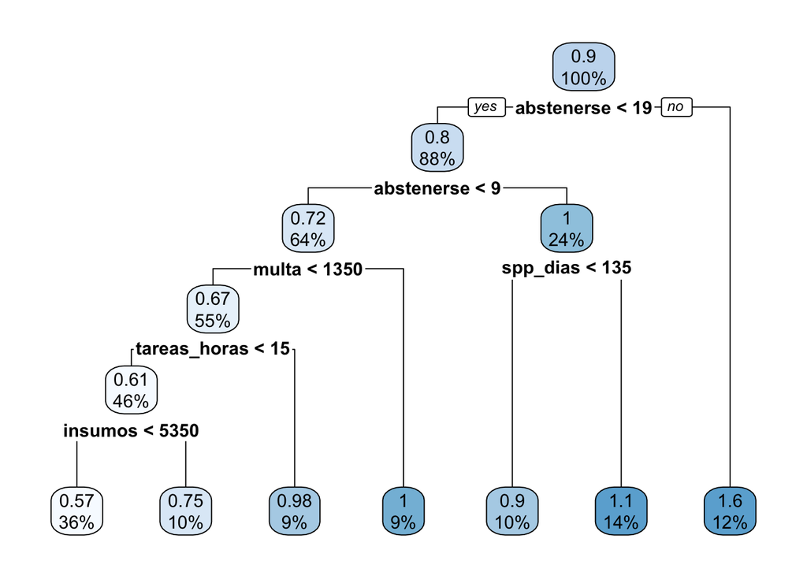

```r
rpart.plot(cart_tune_100$finalModel)
```

Sin embargo con 1 de alcohol en sangre puede obtenerse una obstención de coducción menor a 9 días, pero una multa mayor a 1350 pesos. Finalmente, con un alcohol en sangre de 0.57 (en promedio la más baja) puede obtenerse una condena a entregar insumos por menos de $5350 pesos, menos de 15 horas de trabajos comunitarios, una multa menor a $1350 y una abstención menor de 9 días.

Este cuadro permite saber más o menos qué es probable esperar de acuerdo al alcohol en sangre detectado.

Para probar el modelo, deberemos entrenar un árbol y testearlo con el dataset respectivo.

```r
fitControl <- trainControl(method="cv",
                            number=10)

cart_tune <- train(valor ~ . ,
                 data = entrenamiento, #80% del dataset
                 method = "rpart2",
                 trControl = fitControl,
                 tuneGrid = grid
)
cart_tune
```

```
## CART
##
## 75 samples
## 11 predictors
##
## No pre-processing
## Resampling: Cross-Validated (10 fold)
## Summary of sample sizes: 68, 67, 68, 69, 67, 67, ...
## Resampling results across tuning parameters:
##
##   maxdepth  RMSE       Rsquared   MAE
##   3         0.3419970  0.4360922  0.2367980
##   4         0.3314428  0.4560083  0.2325803
##   5         0.3312589  0.4540760  0.2311823
##   6         0.3312589  0.4540760  0.2311823
##   7         0.3312589  0.4540760  0.2311823
##   8         0.3312589  0.4540760  0.2311823
##
## RMSE was used to select the optimal model using the smallest value.
## The final value used for the model was maxdepth = 5.
```

Y lo graficamos

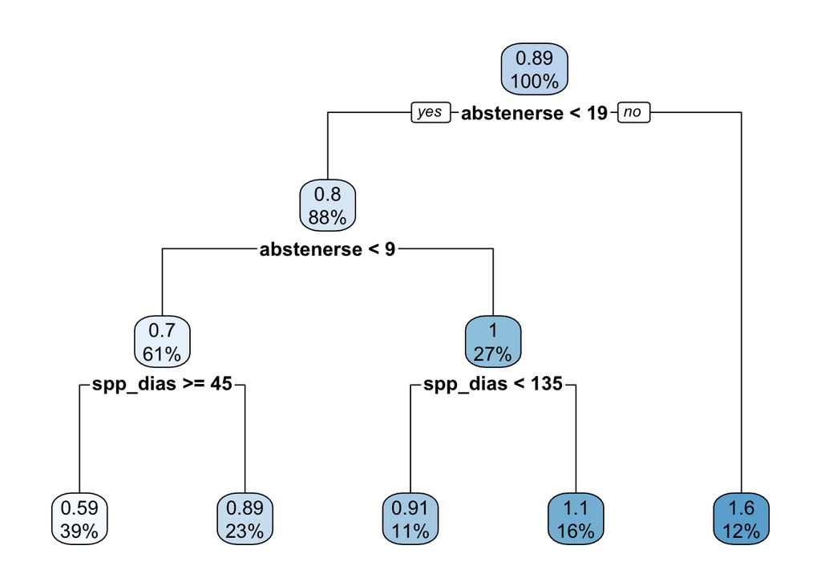

```r
rpart.plot(cart_tune$finalModel)
```

Por último, vamos a correr el modelo predictivo sobre el dataset de prueba (`test`) a ver cómo se comporta, y lo comparamos con el `valor` real del dataset.

```r
valor_predictivo <- predict(cart_tune, prueba)


resultado_cart <- tibble(real = prueba$valor,
                         M_arbol = round(valor_predictivo,2),
                         diferencia = M_arbol - real)

knitr::kable(resultado_cart) %>%
  kable_styling(full_width = FALSE)
```

| real | M_arbol | diferencia |
| --- | --- | --- |
| 0.52 | 0.89 | 0.37 |
| 0.67 | 0.89 | 0.22 |
| 0.58 | 0.89 | 0.31 |
| 1.38 | 0.89 | -0.49 |
| 0.56 | 0.59 | 0.03 |
| 0.83 | 0.91 | 0.08 |
| 1.08 | 0.89 | -0.19 |
| 0.66 | 0.89 | 0.23 |
| 0.54 | 0.59 | 0.05 |
| 1.34 | 1.59 | 0.25 |
| 0.64 | 0.59 | -0.05 |
| 0.78 | 0.59 | -0.19 |
| 0.71 | 0.59 | -0.12 |
| 1.04 | 1.10 | 0.06 |
| 1.97 | 1.59 | -0.38 |
| 1.26 | 0.59 | -0.67 |

En promedio, el valor predicho estuvo -0.03062 alejado del valor real, con una dispersión de 0.2963887.

## Modelo 3. Random Forest

El tercer modelo predictivo será un ensamble de random forest. En los ensambles, se juntan varios árboles de decisión (un bosque *forest*) y se construye un modelo más fuerte a partir de varios más débiles.

Veamos. Vamos a usar el mismo esquema de validación cruzada ya utilizado en los dos modelos anteriores.

```r
# Generar grid
grid_rf <- expand.grid(mtry=c(2,3,4,5,7,10),
                       min.node.size=c(1,3,5),
                       splitrule = c("extratrees", "variance")
                       )
modelo_ranger <- train(valor ~.,
                       data = entrenamiento,
                       method = "ranger",
                       trControl = fitControl,
                       tuneGrid = grid_rf,
                       importance = 'impurity'
                      )

modelo_ranger$finalModel
```

```
## Ranger result
##
## Call:
##  ranger::ranger(dependent.variable.name = ".outcome", data = x,      mtry = min(param$mtry, ncol(x)), min.node.size = param$min.node.size,      splitrule = as.character(param$splitrule), write.forest = TRUE,      probability = classProbs, ...)
##
## Type:                             Regression
## Number of trees:                  500
## Sample size:                      75
## Number of independent variables:  11
## Mtry:                             7
## Target node size:                 1
## Variable importance mode:         impurity
## Splitrule:                        extratrees
## OOB prediction error (MSE):       0.04162273
## R squared (OOB):                  0.7614675
```

```r
modelo_ranger$bestTune
```

```
##    mtry  splitrule min.node.size
## 25    7 extratrees             1
```

Y ahora podemos usar este modelo para predecir el subset de prueba, y luego hacer una tabla para analizar cuán preciso es el modelo.

```r
prediccion_ranger <- predict(modelo_ranger, prueba)

resultado_ranger <- tibble(real = prueba$valor,
                           M_ranger = round(prediccion_ranger,2),
                           diferencia = M_ranger - real)

knitr::kable(resultado_ranger) %>%
  kable_styling(full_width = FALSE)
```

| real | M_ranger | diferencia |
| --- | --- | --- |
| 0.52 | 0.95 | 0.43 |
| 0.67 | 0.67 | 0.00 |
| 0.58 | 0.60 | 0.02 |
| 1.38 | 0.75 | -0.63 |
| 0.56 | 0.57 | 0.01 |
| 0.83 | 0.91 | 0.08 |
| 1.08 | 1.07 | -0.01 |
| 0.66 | 0.60 | -0.06 |
| 0.54 | 0.59 | 0.05 |
| 1.34 | 1.36 | 0.02 |
| 0.64 | 1.21 | 0.57 |
| 0.78 | 0.68 | -0.10 |
| 0.71 | 0.68 | -0.03 |
| 1.04 | 1.15 | 0.11 |
| 1.97 | 1.73 | -0.24 |
| 1.26 | 0.96 | -0.30 |

Asimismo, podemos identificar las variables más importantes para la predicción del valor, que es lo que el operador jurídico deberá mirar al momento de fijar la sentencia.

```r
varImp(modelo_ranger)
```

```
## ranger variable importance
##
##                Overall
## abstenerse     100.000
## tareas_horas    43.913
## spp_dias        43.452
## insumos         40.516
## curso           19.845
## abreviado        7.338
## multa            6.024
## absolucion       3.155
## probation        2.105
## inhabilitacion   1.536
## arresto          0.000
```

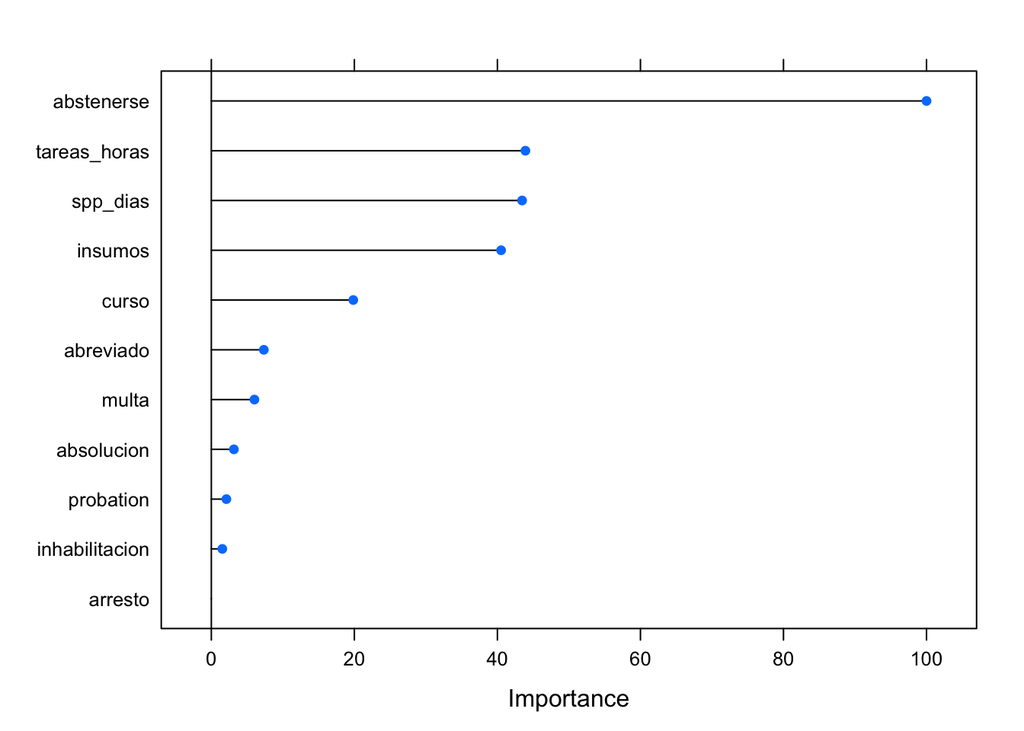

```r
plot(varImp(modelo_ranger))
```

# Conclusiones

Despues de analizar estos modelos, podemos comparar las predicciones de cada uno sobre el dataset de prueba, y analizar cuál fue el más preciso.

```r
comparativa <- tibble(M_regresion = resultado_regresion$M_regresion,
                      M_arbol = resultado_cart$M_arbol,
                      M_ranger = resultado_ranger$M_ranger,
                      Real = prueba$valor,
                      dif_reg = abs(resultado_regresion$diferencia),
                      dif_arbol = abs(resultado_cart$diferencia),
                      dif_ranger = abs(resultado_ranger$diferencia))
comparativa <- comparativa %>%
  mutate(mas_preciso = case_when(dif_reg < dif_arbol & dif_reg< dif_ranger ~ "Regresion",
                                 dif_ranger<dif_reg & dif_ranger<dif_arbol ~ "Ranger",
                                 dif_arbol<dif_ranger & dif_arbol< dif_reg ~ "Arbol"))%>%
  select(-dif_reg, -dif_ranger, -dif_arbol)

kable(comparativa) %>%
  kable_styling(full_width = FALSE)
```

| M_regresion | M_arbol | M_ranger | Real | mas_preciso |
| --- | --- | --- | --- | --- |
| 0.94 | 0.89 | 0.95 | 0.52 | Arbol |
| 0.46 | 0.89 | 0.67 | 0.67 | Ranger |
| 0.67 | 0.89 | 0.60 | 0.58 | Ranger |
| 1.05 | 0.89 | 0.75 | 1.38 | Regresion |
| 0.76 | 0.59 | 0.57 | 0.56 | Ranger |
| 0.85 | 0.91 | 0.91 | 0.83 | Regresion |
| 1.05 | 0.89 | 1.07 | 1.08 | Ranger |
| 0.67 | 0.89 | 0.60 | 0.66 | Regresion |
| 0.67 | 0.59 | 0.59 | 0.54 | NA |
| 1.63 | 1.59 | 1.36 | 1.34 | Ranger |
| 0.75 | 0.59 | 1.21 | 0.64 | Arbol |
| 0.88 | 0.59 | 0.68 | 0.78 | NA |
| 0.88 | 0.59 | 0.68 | 0.71 | Ranger |
| 1.12 | 1.10 | 1.15 | 1.04 | Arbol |
| 1.62 | 1.59 | 1.73 | 1.97 | Ranger |
| 0.68 | 0.59 | 0.96 | 1.26 | Ranger |

```r
preciso <- comparativa %>%
  group_by(mas_preciso) %>%
  summarise(cant = n()) %>%
  mutate(porc = round(cant/sum(cant),2)*100) %>%
  arrange(desc(cant))
kable(preciso) %>%
  kable_styling(full_width = FALSE)
```

| mas_preciso | cant | porc |
| --- | --- | --- |
| Ranger | 8 | 50 |
| Arbol | 3 | 19 |
| Regresion | 3 | 19 |
| NA | 2 | 12 |

De este modo, vemos que el modelo que más veces es más preciso es el modelo Ranger, con 8 de 16predicciones más cercanas al valor real.

El modelo más preciso fue el del ensamble *Random Forest*. A la misma conclusión llegamos si comparamos el $R^2$.

```r
R2 <- tibble(M_regresion  = round(regresion$results[3],5),
             M_arbol = max(cart_tune_100$results[3]),
             M_ranger = modelo_ranger$finalModel[11])
kable(R2) %>%
  kable_styling(full_width = FALSE)
```

| M_regresion | M_arbol | M_ranger |
| --- | --- | --- |
| 0.61155 | 0.5394214 | 0.761467548676703 |

[^1]: Entre ellos, por ejemplo, el trabajo de Paola Bergallo sobre sentencias en materia de salud, “¿Se logra justicia a pesar de la ‘rutinización’ de los reclamos individuales de cobertura?, en Alicia Ely Yamin y Siri Gloppen (coord), *La lucha por los derechos de la Salud*, Siglo XXI, 2013. O mucha de la obra de Gustavo Arballo sobre la Corte Suprema, por ejemplo”La Corte Suprema frente al Gobierno. Cuantificando datos sobre casos políticamente perfilados en el período 1984-2014“, disponible en https://www.academia.edu/14848328/. Lila García analizó sentencias de expulsiones a migrantes en”Política migratoria y delitos: expulsión por causales penales y derechos bajo la actual ley argentina de Migraciones“, en http://www.scielo.br/pdf/remhu/v23n45/1980-8585-REMHU-23-45-197.pdf. También un análisis propio de las sentencias habitacionales de la justicia de la Ciudad,”El impacto de Quisbert Castro en la Jurisprudencia de la Cámara Contencioso Administrativo y Tributario de la Ciudad de Buenos Aires. Un análisis empírico", en https://www.academia.edu/31739430/
[^2]: Hay una gran cantidad de repositorios públicos, tanto a nivel nacional como provincial o local, por ejemplo https://datos.gob.ar/, https://datos.hcdn.gob.ar/, https://www.senado.gov.ar/micrositios/DatosAbiertos/, http://consejoabierto.pjn.gov.ar/, http://datos.csjn.gov.ar/, etc.
[^3]: Del mismo modo que el estado civil de una persona cambia cuando un funcionario competente manifiesta “los declaro unidos en matrimonio”
[^4]: Por el tipo de automatización, solo obtendré una mayor probabilidad de que el nombre sea de mujer o de varón, y descuento desde ya que habrá varios resultados erróneos.
[^5]: Esto podría distorsionar algunos datos, ya que no es lo mismo la inexistencia de la respuesta a que la respuesta sea `0`. Pero aún en esos casos, donde la respuesta es inexistente porque no corresponde, no deja de ser correcto que la respusta es `0`.
[^6]: Se podría predecir en base a los otros resultados si probablemente fuera varon o mujer, o la edad, pero me parece más conveniente eliminar directamente estas variables.